# Problem Set 3

## About this file

This is the Yicun Duan’s (umich id: 62178151) report of STAT 506’s Problem Set 3. Here is the link to my [GitHub repository](https://github.com/YicunDuanUMich/r_hw03).

## Problem 1

### a

We merge VIX_D and DEMO_D on variable `SEQN` to create a single dataset. We use command `display _N` to show that the total sample size is 6980. The instructions of command `import sasxport 5` and `merge` can be found in [import_doc](https://www.stata.com/manuals13/dimportsasxport.pdf) and [merge_doc](https://www.stata.com/manuals/dmerge.pdf), respectively.

```stata
. clear

. // Load VIX_D.
. import sasxport5 "L:\umich\stat506\r_hw03\hw03\data\VIX_D.XPT", clear

. // Save VIX_D into a dta file `vid_d.dta`.
. save "L:\umich\stat506\r_hw03\hw03\data\vid_d.dta", replace
(file L:\umich\stat506\r_hw03\hw03\data\vid_d.dta not found)
file L:\umich\stat506\r_hw03\hw03\data\vid_d.dta saved

.
. // Load DEMO_D.
. import sasxport5 "L:\umich\stat506\r_hw03\hw03\data\DEMO_D.XPT", clear

. // Save DEMO_D into a dta file `demo_d.dta`.
. save "L:\umich\stat506\r_hw03\hw03\data\demo_d.dta", replace
(file L:\umich\stat506\r_hw03\hw03\data\demo_d.dta not found)
file L:\umich\stat506\r_hw03\hw03\data\demo_d.dta saved

.
. // Open the `vid_dta`.
. use "L:\umich\stat506\r_hw03\hw03\data\vid_d.dta", clear

. // Merge data on the key SEQN and only keep the records which matched.
. merge 1:1 seqn using "L:\umich\stat506\r_hw03\hw03\data\demo_d.dta",  keep(match)

    Result                      Number of obs
    -----------------------------------------
    Not matched                             0
    Matched                             6,980  (_merge==3)
    -----------------------------------------

.
. // Show the total number.
. display _N
6980
```

We rename the columns according to the instruction of [VIX_D](https://wwwn.cdc.gov/Nchs/Nhanes/2005-2006/VIX_D.htm) and [DEMO_D](https://wwwn.cdc.gov/Nchs/Nhanes/2005-2006/DEMO_D.htm). `viq220` shows whether the respondents wear glasses/contact lenses for distance, where `1` refers to Yes, `2` refers to No and `9` refers to “Don’t know”. The `ridageyr` is the age at screening adjudicated, ranging from 0 to 85. `riagendr` is the gender of the sample person, where `1` represents Male and `2` represents Female. `ridreth1` records the race information, with `1, 2, 3, 4, 5` as the signs of five different races. `indfmpir` indicates the continuous variable Poverty Income Ratio (PIR) with minimum 0.0 and maximum 5.0.

```stata
. // Rename the columns for easy understanding.
. rename viq220 glass_wear

. rename ridageyr age_year

. rename riagendr gender

. rename ridreth1 race

. rename indfmpir pir
```

### b

You can see our table, which demonstrates the proportion of respondents within each 10-year age bracket (e.g. 0-9, 10-19, 20-29, etc) who wear glasses/contact lenses for distance vision, in the output of `tabulate age_categories`. We refer to the Example 3 of [tabulate_doc](https://www.stata.com/manuals/rtabulateoneway.pdf) to craft this table.

```stata
. preserve

.
. // Keep the records of respondents who wear glasses/contact lenses for distance vision.
. keep if (glass_wear == 1 & !missing(glass_wear)) ///
>                 & (age_year >= 0 & !missing(age_year))
(4,215 observations deleted)

. // Generate a new variable to show the age categories.
. generate age_categories=recode(age_year, 9, 19, 29, 39, 49, 59, 69, 79, 89)

. label define rename_age_cat 9 "[0, 9]" 19 "[10, 19]" 29 "[20, 29]" 39 "[30, 39]" ///
>                             49 "[40, 49]" 59 "[50, 59]" 69 "[60, 69]" 79 "[70, 79]" ///
>                             89 "[80, 89]"

. // Rename the labels for clear display.
. label values age_categories rename_age_cat

. label variable age_categories "Age Categories"

. tabulate age_categories

        Age |
 Categories |      Freq.     Percent        Cum.
------------+-----------------------------------
   [10, 19] |        670       24.23       24.23
   [20, 29] |        306       11.07       35.30
   [30, 39] |        269        9.73       45.03
   [40, 49] |        286       10.34       55.37
   [50, 59] |        335       12.12       67.49
   [60, 69] |        392       14.18       81.66
   [70, 79] |        299       10.81       92.48
   [80, 89] |        208        7.52      100.00
------------+-----------------------------------
      Total |      2,765      100.00

.
. restore
```

### c

We fit three logistic regression models to predict whether a respondent wears glasses/contact lenses for distance vision with age (i.e. model `gw_a`) / age, race, gender (i.e., model `gw_arg`) / age, race, gender, Poverty Income Ratio (i.e., model `gw_argp`) as predictors. The summary of the estimated odds ratios for the coefficients in each model, along with the sample size for the model, the pseudo-$R^2$, and AIC values, can be found in matrix `report_matrix`. How to use logistic regression model is discussed in [logistic_regression](https://www.stata.com/features/overview/logistic-regression/).

Before building the models, we first clean the data to remove the missing values and invalid values.

```stata
. // Data clean.
. // Remove the missing data and invalid data from glass_wear and age_year.
. keep if (glass_wear == 1 | glass_wear == 2) & !missing(glass_wear) ///
>                 & age_year >= 0 & !missing(age_year)
(435 observations deleted)

. // Remove the missing data from race and gender.
. keep if !missing(race) & !missing(gender)
(0 observations deleted)

. // Remove the missing data from pir.
. keep if !missing(pir)
(298 observations deleted)
```

We build the model `gw_a` and store its estimatioin results into matrices.

```stata
. // Build model `gw_a`.
.
. // Originally, 1 means the respondent wears glasses,
. // and 2 means the repondent doesn't wear glasses.
. // We replace glass_wear == 2 with 1.
. replace glass_wear = 0 if glass_wear == 2
(3,592 real changes made)

. // Fit logistic regression model with glass_wear as response and age as predictor.
. logistic glass_wear c.age_year

Logistic regression                                     Number of obs =  6,247
                                                        LR chi2(1)    = 403.24
                                                        Prob > chi2   = 0.0000
Log likelihood = -4057.9357                             Pseudo R2     = 0.0473

------------------------------------------------------------------------------
  glass_wear | Odds ratio   Std. err.      z    P>|z|     [95% conf. interval]
-------------+----------------------------------------------------------------
    age_year |   1.024519   .0012701    19.54   0.000     1.022032    1.027011
       _cons |   .2926507   .0159899   -22.49   0.000     .2629309    .3257299
------------------------------------------------------------------------------
Note: _cons estimates baseline odds.

. // Estimate AIC.
. estat ic

Akaike's information criterion and Bayesian information criterion

-----------------------------------------------------------------------------
       Model |          N   ll(null)  ll(model)      df        AIC        BIC
-------------+---------------------------------------------------------------
           . |      6,247  -4259.553  -4057.936       2   8119.871   8133.351
-----------------------------------------------------------------------------
Note: BIC uses N = number of observations. See [R] IC note.

. // Store the estimation results.
. // `e(b)` is coefficients.
. // `e(N)` is sample size.
. // `r2_p` is the pseudo R^2.
. // `r(S)[1, 5]` is the AIC value.
. matrix gw_a_coef = e(b)

. local gw_a_N e(N)

. local gw_a_r2_p e(r2_p)

. local gw_a_aic r(S)[1, 5]

. matrix gw_a_nra_matrix = (`gw_a_N', `gw_a_r2_p', `gw_a_aic')

. // Save the model.
. estimates store gw_a
```

We build the model `gw_arg` and store its estimatioin results into matrices.

```stata
. // Build model `gw_arg`
.
. // Fit logistic regression model with glass_wear as response,
. // age, race, gender as predictors.
. logistic glass_wear c.age i.race i.gender

Logistic regression                                     Number of obs =  6,247
                                                        LR chi2(6)    = 584.03
                                                        Prob > chi2   = 0.0000
Log likelihood = -3967.5377                             Pseudo R2     = 0.0686

------------------------------------------------------------------------------
  glass_wear | Odds ratio   Std. err.      z    P>|z|     [95% conf. interval]
-------------+----------------------------------------------------------------
    age_year |   1.022587   .0013241    17.25   0.000     1.019995    1.025185
             |
        race |
          2  |   1.168215   .1956975     0.93   0.353     .8412612    1.622238
          3  |   1.894799   .1363362     8.88   0.000     1.645571    2.181773
          4  |     1.2924   .1014773     3.27   0.001     1.108056    1.507412
          5  |   1.882885   .2609691     4.57   0.000     1.434983    2.470592
             |
    2.gender |   1.652027   .0892984     9.29   0.000     1.485958    1.836656
       _cons |   .1652317   .0132454   -22.46   0.000     .1412078    .1933428
------------------------------------------------------------------------------
Note: _cons estimates baseline odds.

. // Estimate AIC.
. estat ic

Akaike's information criterion and Bayesian information criterion

-----------------------------------------------------------------------------
       Model |          N   ll(null)  ll(model)      df        AIC        BIC
-------------+---------------------------------------------------------------
           . |      6,247  -4259.553  -3967.538       7   7949.075   7996.254
-----------------------------------------------------------------------------
Note: BIC uses N = number of observations. See [R] IC note.

. // Store the estimation results.
. matrix gw_arg_coef = e(b)

. local gw_arg_N e(N)

. local gw_arg_r2_p e(r2_p)

. local gw_arg_aic r(S)[1, 5]

. matrix gw_arg_nra_matrix = (`gw_a_N', `gw_a_r2_p', `gw_a_aic')

. // Save the model.
. estimates store gw_arg
```

We build the model `gw_argp` and store its estimatioin results into matrices.

```stata
. // Build model `gw_argp`
.
. // Fit a logistic regression model with glass_wear as reponse,
. // age, race, gender and pir as predictors.
. logistic glass_wear c.age i.race i.gender c.pir

Logistic regression                                     Number of obs =  6,247
                                                        LR chi2(7)    = 625.30
                                                        Prob > chi2   = 0.0000
Log likelihood = -3946.9041                             Pseudo R2     = 0.0734

------------------------------------------------------------------------------
  glass_wear | Odds ratio   Std. err.      z    P>|z|     [95% conf. interval]
-------------+----------------------------------------------------------------
    age_year |   1.022436    .001324    17.14   0.000     1.019845    1.025035
             |
        race |
          2  |   1.123021   .1889653     0.69   0.490     .8075333    1.561764
          3  |   1.651244   .1240886     6.67   0.000     1.425098    1.913277
          4  |   1.230456   .0974736     2.62   0.009     1.053503     1.43713
          5  |   1.703572   .2387583     3.80   0.000     1.294384    2.242114
             |
    2.gender |   1.675767   .0910025     9.51   0.000      1.50657    1.863967
         pir |   1.120301   .0198376     6.42   0.000     1.082087    1.159865
       _cons |   .1331659   .0116903   -22.97   0.000     .1121161    .1581678
------------------------------------------------------------------------------
Note: _cons estimates baseline odds.

. // Estimate AIC.
. estat ic

Akaike's information criterion and Bayesian information criterion

-----------------------------------------------------------------------------
       Model |          N   ll(null)  ll(model)      df        AIC        BIC
-------------+---------------------------------------------------------------
           . |      6,247  -4259.553  -3946.904       8   7909.808   7963.727
-----------------------------------------------------------------------------
Note: BIC uses N = number of observations. See [R] IC note.

. // Store the estimation results.
. matrix gw_argp_coef = e(b)

. local gw_argp_N e(N)

. local gw_argp_r2_p e(r2_p)

. local gw_argp_aic r(S)[1, 5]

. matrix gw_argp_nra_matrix = (`gw_a_N', `gw_a_r2_p', `gw_a_aic')

. // Save the model.
. estimates store gw_argp
```

Then, we use MATA to create a matrix which summarizes the estimation results of three models.

```stata
. // Use MATA to build a table (i.e., a matrix) summarizing the estimation results of three models.
. mata:
------------------------------------------------- mata (type end to exit) -----------------------------------------------------------------------------------------
: // Load matrix from STATA.
: gw_a_coef = st_matrix("gw_a_coef")

: gw_a_nra_matrix = st_matrix("gw_a_nra_matrix")

: gw_arg_coef = st_matrix("gw_arg_coef")

: gw_arg_nra_matrix = st_matrix("gw_arg_nra_matrix")

: gw_argp_coef = st_matrix("gw_argp_coef")

: gw_argp_nra_matrix = st_matrix("gw_argp_nra_matrix")

:
: // Combine the matrices to formulate a succinct matrix.
: gw_a = (exp(gw_a_coef[1, 1]), J(1, 8, 0), exp(gw_a_coef[1, 2]), gw_a_nra_matrix)

: gw_arg = (exp(gw_arg_coef[1, 1..8]), 0, exp(gw_arg_coef[1, 9]), gw_arg_nra_matrix)

: gw_argp = (exp(gw_argp_coef), gw_argp_nra_matrix)

: report_matrix = (gw_a \ gw_arg \ gw_argp)

:
: // Put the matrix back to STATA.
: st_matrix("report_matrix", report_matrix)

: end
-------------------------------------------------------------------------------------------------------------------------------------------------------------------
```

We display this matrix. Please note that `0` means that the corresponding coefficient doesn’t exist in a certain model.

```stata
. // Rename the columns and rows of the report matrix for clear display.
. matrix colnames report_matrix = "age_year" ///
>                                 "1b.race" "2.race" "3.race" "4.race" "5.race" ///
>                                 "1b.gender" "2.gender" ///
>                                 "pir" "_cons" ///
>                                 "N" "R2" "AIC"

. matrix rownames report_matrix = "gw_a" "gw_arg" "gw_argp"

.
. matrix list report_matrix

report_matrix[3,13]
                           1b.         2.         3.         4.         5.        1b.         2.
          age_year       race       race       race       race       race     gender     gender        pir      _cons          N         R2        AIC
   gw_a  1.0245185          0          0          0          0          0          0          0          0  .29265072       6247  .04733303  8119.8715
 gw_arg  1.0225868          1  1.1682149   1.894799  1.2923996  1.8828854          1  1.6520269          0  .16523167       6247  .06855546  7949.0753
gw_argp  1.0224363          1  1.1230212  1.6512439  1.2304557  1.7035717          1  1.6757675  1.1203014   .1331659       6247  .07339952  7909.8082
```

### d

We first reload the third model `gw_argp` and replay the regression.

```stata
. // Reload the third model.
. estimates restore gw_argp
(results gw_argp are active now)

. // Replay the regression.
. logistic

Logistic regression                                     Number of obs =  6,247
                                                        LR chi2(7)    = 625.30
                                                        Prob > chi2   = 0.0000
Log likelihood = -3946.9041                             Pseudo R2     = 0.0734

------------------------------------------------------------------------------
  glass_wear | Odds ratio   Std. err.      z    P>|z|     [95% conf. interval]
-------------+----------------------------------------------------------------
    age_year |   1.022436    .001324    17.14   0.000     1.019845    1.025035
             |
        race |
          2  |   1.123021   .1889653     0.69   0.490     .8075333    1.561764
          3  |   1.651244   .1240886     6.67   0.000     1.425098    1.913277
          4  |   1.230456   .0974736     2.62   0.009     1.053503     1.43713
          5  |   1.703572   .2387583     3.80   0.000     1.294384    2.242114
             |
    2.gender |   1.675767   .0910025     9.51   0.000      1.50657    1.863967
         pir |   1.120301   .0198376     6.42   0.000     1.082087    1.159865
       _cons |   .1331659   .0116903   -22.97   0.000     .1121161    .1581678
------------------------------------------------------------------------------
Note: _cons estimates baseline odds.
```

As shown in the output of logistic regression model, the z-statistic of `2.gender` is 9.51 with p-value 0.000, which demonstrates that the estimated odds of `2.gender` is significantly different from 0 and, in other words, odds of men and women being wears of glasses/contact lenses for distance vision differs.

We also test the proportion of wears of glasses/contact lenses for distance vision, with respect to male and female. The result of `tabulate` shows that there are about 37.14% men wearing glasses/contact lenses which is lower than that of women (i.e., 47.62%).

```stata
. // Show the the proportion of wearers of glasses/contact lenses for distance vision
. // with respect to men and women
. label define rename_gender 1 "Male" 2 "Female", replace

. label values gender rename_gender

. label define rename_glass_wear 0 "No" 1 "Yes", replace

. label values glass_wear rename_glass_wear

. tabulate gender glass_wear, row

+----------------+
| Key            |
|----------------|
|   frequency    |
| row percentage |
+----------------+

           |    Glasses/contact
           |    lenses worn for
           |       distance
    Gender |        No        Yes |     Total
-----------+----------------------+----------
      Male |     1,919      1,134 |     3,053
           |     62.86      37.14 |    100.00
-----------+----------------------+----------
    Female |     1,673      1,521 |     3,194
           |     52.38      47.62 |    100.00
-----------+----------------------+----------
     Total |     3,592      2,655 |     6,247
           |     57.50      42.50 |    100.00

.
```

## Problem 2

### a

We first load the dataset and define the `sakila_query` function.

**The code for Problem 2-a**

```r
rm(list = ls())
# Reset working directory.
setwd("O:\\dyc\\OneDrive - Umich\\umich\\stat506\\r_hw03\\hw03")

# Load dataset
library(DBI)
sakila <- dbConnect(RSQLite::SQLite(), "./data/sakila-sqlite3-main/sakila_master.db")


#' Conduct SQL query on dataset sakila.
#'
#' @param query_str a SQL query string.
#'
#' @return the SQL query result.
#' @export
#'
#' @examples
sakila_query <- function(query_str) {
  return(dbGetQuery(sakila, query_str))
}
```

We use SQL query to answer the question “Aside from English, what language is most common for films? Answer this with a single SQL query.”.

**The code for Problem 2-a**

```r
# Table `film` left joins table `language` on key `language_id`.
# Then, we count the number of films according to their `language_id`.
# Finally, we rearrange the results in descending order.
sakila_query("
SELECT l.name AS language_name, COUNT(f.language_id) AS language_count
  FROM film AS f
       LEFT JOIN language AS l
              ON f.language_id = l.language_id
 WHERE f.language_id != 1
 GROUP BY f.language_id
 ORDER BY -language_count
 LIMIT 5
             ")
```

```
[1] language_name  language_count
<0 rows> (or 0-length row.names)
```

The output demonstrates that there is no non-English film.

### b

We first use SQL query to answer the question “What genre of movie is the most common in the data, and how many movies are of this genre?”.

**SQL implementation**:

**The code for Problem 2-b**

```r
# Table `film` left joins `film_category` on key `film_id`.
# The merged table then left joins `category` on key `category_id`.
# We count the number of films according to their `category_id`.
# We rearrange the results in descending order.
sakila_query("
SELECT c.name, COUNT(ffc.category_id) AS genre_count
  FROM (SELECT f.film_id, fc.category_id
          FROM film AS f
               LEFT JOIN film_category AS fc
                      ON f.film_id = fc.film_id) AS ffc
        LEFT JOIN category AS c ON ffc.category_id = c.category_id
 GROUP BY ffc.category_id
 ORDER BY -genre_count
 LIMIT 5
             ")
```

```
         name genre_count
1      Sports          74
2     Foreign          73
3      Family          69
4 Documentary          68
5   Animation          66
```

As shown in the outputs, the Sports is the most common genre of movies and there are 74 Sports movies.

We also use R to answer this question and get the same results.

**R implementation**:

**The code for Problem 2-b**

```r
# Extract tables from the dataset.
film_table <- sakila_query("
SELECT *
  FROM film
                           ")
film_category_table <- sakila_query("
SELECT *
  FROM film_category
                                    ")
category_table <- sakila_query("
SELECT *
  FROM category
                               ")

# `film_table` left joins `film_category_table` on the key `film_id`,
# and then we select `film_id` and `category_id` from the merged table.
ffc_table <- merge(x = film_table, y = film_category_table,
                   by.x = "film_id", by.y = "film_id",
                   all.x = TRUE)[, c("film_id", "category_id")]

# `ffc_table` left joins `category_table` on the key `category_id`,
# and then we select `name` and `category_id` from the merged table.
ffcc_table <- merge(x = ffc_table, y = category_table,
                    by.x = "category_id", by.y = "category_id",
                    all.x = TRUE)[, c("name", "category_id")]

# Count the number of films according to their `category_id`.
genre_names <- vector("character", length = length(unique(ffcc_table$name)))
genre_counts <- vector("double", length = length(unique(ffcc_table$category_id)))
i <- 1
for (id in unique(ffcc_table$category_id)) {
  genre_names[i] <- ffcc_table$name[ which(ffcc_table$category_id == id)[1] ]
  genre_counts[i] <- sum(ffcc_table$category_id == id)
  i <- i + 1
}
genre_result <- data.frame(name = genre_names, genre_counts = genre_counts)

# Order by `genre_counts` in a descending manner.
head(genre_result[order(genre_result$genre_counts, decreasing = TRUE), ])
```

```
          name genre_counts
15      Sports           74
9      Foreign           73
8       Family           69
6  Documentary           68
2    Animation           66
1       Action           64
```

### c

We first use SQL to answer the question “Identify which country or countries have exactly 9 customers.”.

**SQL implementation**:

**The code for Problem 2-c**

```r
# We use "left join" to merge the tables `customer`, `address`, `city` and `country` iteratively.
# During this process, we use the keys `address_id`, `city_id` and `country_id`.
# We then count the number of customers according to their countries.
# We only choose the country which has exactly 9 customers, using `HAVING` command.
# We rearrange the results in descending order.
sakila_query("
SELECT co.country, COUNT(cca.country_id) AS customer_count
  FROM (SELECT ca.customer_id, ci.country_id
          FROM (SELECT c.customer_id, a.address_id, a.city_id
                  FROM customer AS c
                       LEFT JOIN address AS a
                              ON c.address_id = a.address_id) AS ca
                LEFT JOIN city AS ci
                       ON ca.city_id = ci.city_id) AS cca
       LEFT JOIN country AS co
              ON cca.country_id = co.country_id
 GROUP BY cca.country_id
 HAVING customer_count == 9
             ")
```

```
         country customer_count
1 United Kingdom              9
```

The results show that the United Kingdom has exactly 9 customers.

The R implementation also gives the same results.

**R implementation**:

**The code for Problem 2-c**

```r
# Extract tables from dataset.
customer_table <- sakila_query("
SELECT *
  FROM customer
                               ")
address_table <- sakila_query("
SELECT *
  FROM address
                              ")
city_table <- sakila_query("
SELECT *
  FROM city
                              ")
country_table <- sakila_query("
SELECT *
  FROM country
                              ")

# `customer_table` left joins `address_table` on the key `address_id`,
# and then we select `customer_id` `city_id` from the merged table.
ca_table <- merge(x = customer_table, y = address_table,
                  by.x = "address_id", by.y = "address_id",
                  all.x = TRUE)[, c("customer_id", "city_id")]

# `ca_table` left joins `city_table` on the key `city_id`,
# and then we select `customer_id` and `country_id` from the merged table.
cca_table <- merge(x = ca_table, y = city_table,
                   by.x = "city_id", by.y = "city_id",
                   all.x = TRUE)[, c("customer_id", "country_id")]

# `cca_table` left joins `country_table` on the key `country_id`,
# and then we select `customer_id`, `country_id` and `country` from the merged table.
ccca_table <- merge(x = cca_table, y = country_table,
                    by.x = "country_id", by.y = "country_id",
                    all.x = TRUE)[, c("customer_id", "country_id", "country")]

# Count the number of customers in a certain country.
country_names <- vector("character", length = length(unique(ccca_table$country)))
customer_counts <- vector("double", length = length(unique(ccca_table$country_id)))
i <- 1
for (id in unique(ccca_table$country_id)) {
  country_names[i] <- ccca_table$country[ which(ccca_table$country_id == id)[1] ]
  customer_counts[i] <- sum(ccca_table$country_id == id)
  i <- i + 1
}
country_result <- data.frame(country = country_names, customer_counts = customer_counts)

# We show the country which has exactly 9 customers.
country_result[country_result$customer_counts == 9, ]
```

```
           country customer_counts
101 United Kingdom               9
```

## Problem 3

### a

Load the dataset.

**The code for Problem 3-a**

```r
rm(list = ls())
us_500_records <- read.table(
  "./data/us-500/us-500.csv",
  sep = ",",
  header = TRUE)
```

Then, we find the email addresses hosted at domain with TLD “.net” using regular expression.

**The code for Problem 3-a**

```r
email_num <- length(us_500_records$email)

length(
  us_500_records$email[
    grepl("\\.net$", us_500_records$email)
    ]
  ) /
  email_num
```

```
[1] 0.14
```

The result shows that there are 14% email addresses with with TLD “.net”.

### b

**The code for Problem 3-b**

```r
length(
  us_500_records$email[
    grepl("[^a-zA-Z0-9@\\.]+", us_500_records$email)
    ]
  ) /
  email_num
```

```
[1] 0.248
```

There are about 24.8% email addresses having at least one non-alphanumeric character.

### c

**The code for Problem 3-c**

```r
all_phones <- c(us_500_records$phone1, us_500_records$phone2)
# Extract the area codes using `substr`.
area_code_all_phones <- sapply(all_phones, substr, start = 1, stop = 3, USE.NAMES = FALSE)

# Count the number of phones according to their area codes.
area_codes <- vector("character", length = length(unique(area_code_all_phones)))
area_code_counts <- vector("double", length = length(unique(area_code_all_phones)))
i <- 1
for (area_code in unique(area_code_all_phones)) {
  area_codes[i] <- area_code
  area_code_counts[i] <- sum(area_code_all_phones == area_code)
  i <- i + 1
}
area_code_count_result <- data.frame(area_codes = area_codes, area_code_counts = area_code_counts)

# Order by `area_code_counts` in a descending manner.
head(area_code_count_result[
  order(area_code_count_result$area_code_counts, decreasing = TRUE), ])
```

```
   area_codes area_code_counts
56        973               36
10        410               28
11        215               28
27        212               28
31        201               24
36        305               18
```

The most common area code is “973” which includes 36 phones.

### d

**The code for Problem 3-d**

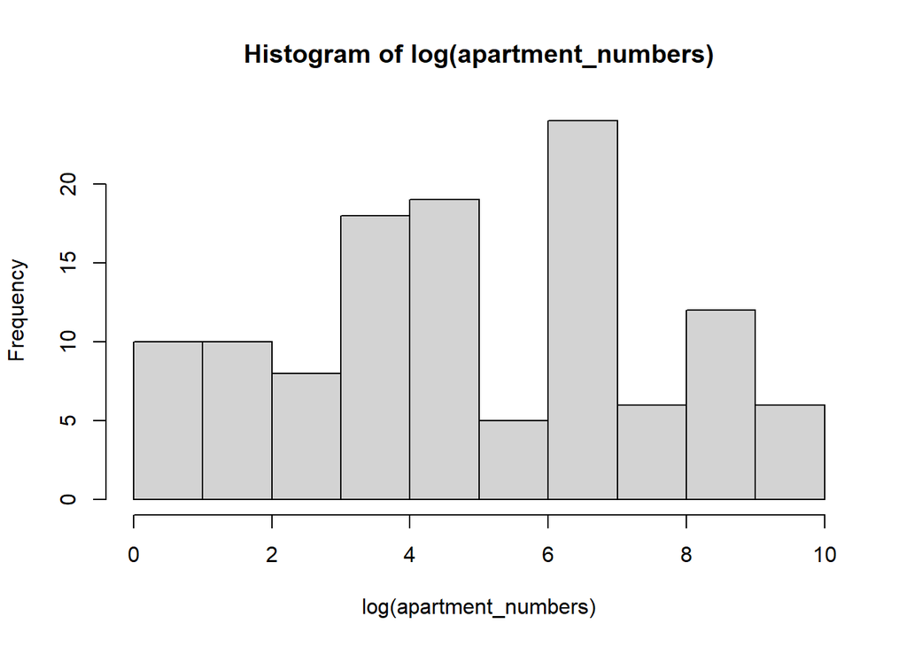

```r
# We use `gsub` to extract apartment numbers.
# `gsub` will substitute the original address string with the extracted apartment number, if the regular expression matches the address.
apartment_numbers_str <- gsub(".*[ #]+([0-9]+)$",
                              "\\1",
                              us_500_records$address)
# If the regular expression doesn't match the address, it will not change the address string to apartment number, but keep the address string unchanged.
# So, we only keep the strings which only contain number.
apartment_numbers_str <- apartment_numbers_str[grepl("^[0-9]+$", apartment_numbers_str)]
# Transfer the string to number.
apartment_numbers <- as.numeric(apartment_numbers_str)

# Draw the log histogram.
hist(log(apartment_numbers))
```

### e

We first write a function `check_benford` to test whether the input digits follow Benford’s law. This function will compare the density of input digits with the standard density of Benford distribution, through a density plot. It also formally tests the goodness of fit through chi-squared test.

**The code for Problem 3-e**

```r
#' Test whether the input digits follow Benford's law.
#'
#' This function will compare the density of input digits with
#' the standard density of Benford distribution, through a density plot.
#' It also formally tests the goodness of fit through chi-squared test.
#'
#' @param input_digits a vector including all sample digits.
#'
#' @return a density plot, the chi-square statistic and its p-value
check_benford <- function(input_digits) {

  #' Get the standard probability of a certain digit,
  #' assuming it follows Benford's law.
  #'
  #' @param d a digit
  #'
  #' @return the Benford probability of the digit `d`.
  benford_dist <- function(d) {
    return(log(1 + 1 / d, base = 10))
  }

  # Count how many times a certain digit appears.
  input_digits_count <- vector("double", length = 9)
  input_digits_density <- vector("double", length = 9)
  n <- length(input_digits)
  for (i in 1:9) {
    input_digits_count[i] <- sum(input_digits == i)
    input_digits_density[i] <- input_digits_count[i] / n
  }

  # Draw the density plot to conduct a comparison
  # between the density of input digits and standard Benford density.
  density_for_plot <- matrix(c(input_digits_density, sapply(1:9, benford_dist)), ncol=2)
  matplot(1:9, density_for_plot,
          type = c("b"), pch=1, col = 3:4,
          xlab = "Digit", ylab = "Density",
          xlim = c(0, 10))
  legend("topright", legend = c("Input", "Benford"), col=3:4, pch=1)

  # Conduct chi-square test
  # chi-square = \sum_{i = 1}^{k} f_i^2 / (n p_i) - n
  benford_chi_square_statistic <- 0
  for (i in 1:9) {
    benford_chi_square_statistic <- benford_chi_square_statistic + input_digits_count[i]^2 / (n * benford_dist(i))
  }
  benford_chi_square_statistic <- benford_chi_square_statistic - n

  # chi-square ~ chisq(df = 9 - 1)
  benford_p_value <- 1 - pchisq(benford_chi_square_statistic, df = 9 - 1)
  cat("Goodness of fit test:\nchi-square-statistic:", benford_chi_square_statistic, ", p-value:", benford_p_value)
}
```

We extract the leading digits of apartment using `substr`, and then pass the leading digits to `check_benford`.

**The code for Problem 3-e**

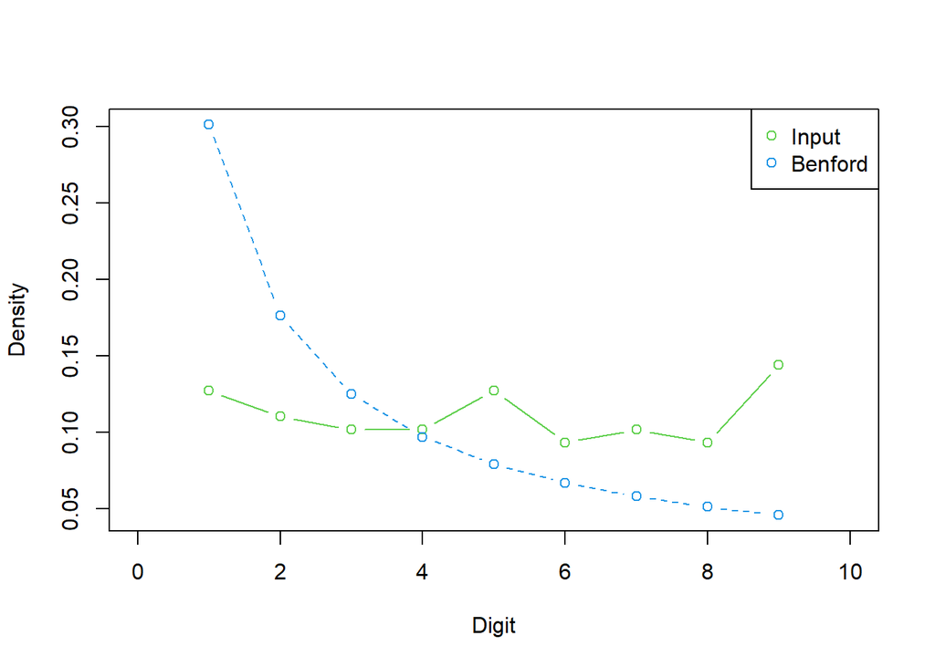

```
Goodness of fit test:
chi-square-statistic: 52.83995 , p-value: 1.158168e-08
```

```r
# We extract the leading digits of apartment numbers.
leading_digits <- as.numeric(
  sapply(
    apartment_numbers_str, substr, start = 1, stop = 1)
  )

# Do the Benford test.
check_benford(leading_digits)
```

As the results shown, except digit 4, there is significant divergence between samples’ density and Benford’s density. And in the chi-squared test, p-value is very small (i.e., $1.158168e-08$), which demonstrates that we can reject the null hypothesis, and, in other words, the leading digits of apartment numbers don’t follow Benford’s law. Therefore, I argue that apartment numbers would not pass as real data.

### f

Similar to the previous section, we test the last digit of the street number.

**The code for Problem 3-f**

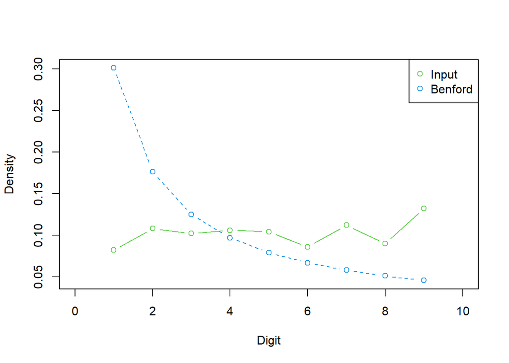

```
Goodness of fit test:
chi-square-statistic: 145.1551 , p-value: 0
```

```r
# We use `gsub` to extract the street numbers.
street_numbers_str <- gsub("^([0-9]+).*$", "\\1", us_500_records$address)
# We only keep the strings which only contain number.
street_numbers_str <- street_numbers_str[grepl("^[0-9]+$", street_numbers_str)]

#' Get the last character of a string.
#'
#' @param x the input string.
#'
#' @return the last character of the input string.
last_char <- function(x){
  substr(x, nchar(x), nchar(x))
}

# We use `last_char` to extract the last character of street number string
# and then convert it to number.
last_digits <- as.numeric(
  sapply(street_numbers_str, last_char)
  )

# Do the Benford test.
check_benford(last_digits)
```